# Project Python Foundations: FoodHub Data Analysis

### Context

The number of restaurants in New York is increasing day by day. Lots of students and busy professionals rely on those restaurants due to their hectic lifestyles. Online food delivery service is a great option for them. It provides them with good food from their favorite restaurants. A food aggregator company FoodHub offers access to multiple restaurants through a single smartphone app.

The app allows the restaurants to receive a direct online order from a customer. The app assigns a delivery person from the company to pick up the order after it is confirmed by the restaurant. The delivery person then uses the map to reach the restaurant and waits for the food package. Once the food package is handed over to the delivery person, he/she confirms the pick-up in the app and travels to the customer's location to deliver the food. The delivery person confirms the drop-off in the app after delivering the food package to the customer. The customer can rate the order in the app. The food aggregator earns money by collecting a fixed margin of the delivery order from the restaurants.

### Objective

The food aggregator company has stored the data of the different orders made by the registered customers in their online portal. They want to analyze the data to get a fair idea about the demand of different restaurants which will help them in enhancing their customer experience. Suppose you are hired as a Data Scientist in this company and the Data Science team has shared some of the key questions that need to be answered. Perform the data analysis to find answers to these questions that will help the company to improve the business.

### Data Description

The data contains the different data related to a food order. The detailed data dictionary is given below.

### Data Dictionary

- order_id: Unique ID of the order
- customer_id: ID of the customer who ordered the food
- restaurant_name: Name of the restaurant
- cuisine_type: Cuisine ordered by the customer
- cost_of_the_order: Cost of the order
- day_of_the_week: Indicates whether the order is placed on a weekday or weekend (The weekday is from Monday to Friday and the weekend is Saturday and Sunday)
- rating: Rating given by the customer out of 5
- food_preparation_time: Time (in minutes) taken by the restaurant to prepare the food. This is calculated by taking the difference between the timestamps of the restaurant's order confirmation and the delivery person's pick-up confirmation.
- delivery_time: Time (in minutes) taken by the delivery person to deliver the food package. This is calculated by taking the difference between the timestamps of the delivery person's pick-up confirmation and drop-off information

### Let us start by importing the required libraries

```python
# Installing the libraries with the specified version.
#!pip install numpy==1.25.2 pandas==1.5.3 matplotlib==3.7.1 seaborn==0.13.1 -q --user
```

**Note**: *After running the above cell, kindly restart the notebook kernel and run all cells sequentially from the start again.*

```python
# import libraries for data manipulation
import numpy as np
import pandas as pd

# import libraries for data visualization
import matplotlib.pyplot as plt
import seaborn as sns
```

### Understanding the structure of the data

```python
from google.colab import drive
drive.mount('/content/drive')
```

```python
# code to read the data
data=pd.read_csv('/content/drive/MyDrive/Python_Course/FoodHub/foodhub_order.csv')
```

```python
# code to view the first 5 rows of the data
data.head()
```

|  | order_id | customer_id | restaurant_name | cuisine_type | cost_of_the_order | day_of_the_week | rating | food_preparation_time | delivery_time |
| --- | --- | --- | --- | --- | --- | --- | --- | --- | --- |
| 0 | 1477147 | 337525 | Hangawi | Korean | 30.75 | Weekend | Not given | 25 | 20 |
| 1 | 1477685 | 358141 | Blue Ribbon Sushi Izakaya | Japanese | 12.08 | Weekend | Not given | 25 | 23 |
| 2 | 1477070 | 66393 | Cafe Habana | Mexican | 12.23 | Weekday | 5 | 23 | 28 |
| 3 | 1477334 | 106968 | Blue Ribbon Fried Chicken | American | 29.20 | Weekend | 3 | 25 | 15 |
| 4 | 1478249 | 76942 | Dirty Bird to Go | American | 11.59 | Weekday | 4 | 25 | 24 |

### **Question 1:** How many rows and columns are present in the data? [0.5 mark]

```python
data.shape
# This displays the shape of the DataFrame to find the number of rows and columns
```

```
(1898, 9)
```

#### Observations:

The data has 1898 rows and 9 collumns.

This indicates that there are 1898 individual records(orders placed) and 9 attributes associated with each record.

### **Question 2:** What are the datatypes of the different columns in the dataset? (The info() function can be used) [0.5 mark]

```python
data.info()     # Display the summary of the DataFrame to show the datatypes of each column
```

```
<class 'pandas.core.frame.DataFrame'>
RangeIndex: 1898 entries, 0 to 1897
Data columns (total 9 columns):
 #   Column                 Non-Null Count  Dtype
---  ------                 --------------  -----
 0   order_id               1898 non-null   int64
 1   customer_id            1898 non-null   int64
 2   restaurant_name        1898 non-null   object
 3   cuisine_type           1898 non-null   object
 4   cost_of_the_order      1898 non-null   float64
 5   day_of_the_week        1898 non-null   object
 6   rating                 1898 non-null   object
 7   food_preparation_time  1898 non-null   int64
 8   delivery_time          1898 non-null   int64
dtypes: float64(1), int64(4), object(4)
memory usage: 133.6+ KB
```

#### Observations:

The Data seems to have no Null or NaN values in any of the collumns.

The data types for the columns in the dataset are as follows:

1) The 'order_id' and 'customer_id' are integer type, which is appropriate since they are as they are numeric id's.

2) 'Restaurant_name' and 'cuisine_type' are of string(object) type, representing names and types respectively.

3) 'cost_of_the_order' is of float type, which suits the numerical cost values.

4) 'day_of_the_week' is of string (object) type, indicating whether the order was placed on a 'Weekday' or 'Weekend'.

5) 'Rating' is of string (object) type, but it contains 'not given' as values. It would be better to treat these as missing values and convert the column to float type.

6) 'food_preparation_time' and delivery_time are of integer type, representing the time in minutes.

### **Question 3:** Are there any missing values in the data? If yes, treat them using an appropriate method. [1 mark]

```python
data['rating'].unique()   # This displays the unique values in the 'rating' column
```

```
array(['Not given', '5', '3', '4'], dtype=object)
```

### Observation

The rating column contains the value 'Not given', which should be treated as a missing value.

```python
data.isnull().sum()   # This displays the number of missing values in each column
```

```
order_id                 0
customer_id              0
restaurant_name          0
cuisine_type             0
cost_of_the_order        0
day_of_the_week          0
rating                   0
food_preparation_time    0
delivery_time            0
dtype: int64
```

#### Observations:

There are no missing values in the data, but the rating column has 'Not given' values which should be converted to NaN.

```python
# Replace 'Not given' with NaN in the 'rating' column
data['rating']=data['rating'].replace('Not given',np.nan)
data['rating'].unique()
```

```
array([nan, '5', '3', '4'], dtype=object)
```

Observations:

The 'Not given' entries in the rating column have been successfully replaced with NaN.

```python
data['rating']=data['rating'].astype(float)
data.head()
```

|  | order_id | customer_id | restaurant_name | cuisine_type | cost_of_the_order | day_of_the_week | rating | food_preparation_time | delivery_time |
| --- | --- | --- | --- | --- | --- | --- | --- | --- | --- |
| 0 | 1477147 | 337525 | Hangawi | Korean | 30.75 | Weekend | NaN | 25 | 20 |
| 1 | 1477685 | 358141 | Blue Ribbon Sushi Izakaya | Japanese | 12.08 | Weekend | NaN | 25 | 23 |
| 2 | 1477070 | 66393 | Cafe Habana | Mexican | 12.23 | Weekday | 5.0 | 23 | 28 |
| 3 | 1477334 | 106968 | Blue Ribbon Fried Chicken | American | 29.20 | Weekend | 3.0 | 25 | 15 |
| 4 | 1478249 | 76942 | Dirty Bird to Go | American | 11.59 | Weekday | 4.0 | 25 | 24 |

#### Observations:

The rating column has been successfully converted to float type, and the 'Not given' values are now NaN. This will help in the analysis later on.

### **Question 4:** Check the statistical summary of the data. What is the minimum, average, and maximum time it takes for food to be prepared once an order is placed? [2 marks]

```python
data.describe().T   # This displays the statistical summary of the DataFrame to show the minimum, average, and maximum values for each column
```

|  | count | mean | std | min | 25% | 50% | 75% | max |
| --- | --- | --- | --- | --- | --- | --- | --- | --- |
| order_id | 1898.0 | 1.477496e+06 | 548.049724 | 1476547.00 | 1477021.25 | 1477495.50 | 1.477970e+06 | 1478444.00 |
| customer_id | 1898.0 | 1.711685e+05 | 113698.139743 | 1311.00 | 77787.75 | 128600.00 | 2.705250e+05 | 405334.00 |
| cost_of_the_order | 1898.0 | 1.649885e+01 | 7.483812 | 4.47 | 12.08 | 14.14 | 2.229750e+01 | 35.41 |
| rating | 1162.0 | 4.344234e+00 | 0.741478 | 3.00 | 4.00 | 5.00 | 5.000000e+00 | 5.00 |
| food_preparation_time | 1898.0 | 2.737197e+01 | 4.632481 | 20.00 | 23.00 | 27.00 | 3.100000e+01 | 35.00 |
| delivery_time | 1898.0 | 2.416175e+01 | 4.972637 | 15.00 | 20.00 | 25.00 | 2.800000e+01 | 33.00 |

### **Question 5:** How many orders are not rated? [1 mark]

```python
data.isnull().sum()
```

```
order_id                   0
customer_id                0
restaurant_name            0
cuisine_type               0
cost_of_the_order          0
day_of_the_week            0
rating                   736
food_preparation_time      0
delivery_time              0
dtype: int64
```

#### Observations:

After converting the 'Not given' values to NaN, it was found that there are 736 orders that are not rated.

### Exploratory Data Analysis (EDA)

### **Question 6:** Explore all the variables and provide observations on their distributions. (Generally, histograms, boxplots, countplots, etc. are used for univariate exploration.) [9 marks]

## 1) Order_id

```python
data['order_id'].shape[0] # Checks the total number of orders
```

```
1898
```

```python
data['order_id'].nunique()  # Checks for unique order IDs to identify duplicates
```

```
1898
```

### Observation:

The order_id column contains 1898 unique values, indicating that there are no duplicate entries for order IDs.

## 2) customer_id

```python
data['customer_id'].shape[0] # Checks the total number of customer entries
```

```
1898
```

### Observation:

There are a total of 1898 customer entries in the dataset.

```python
data['customer_id'].nunique() # Check for unique customer IDs to identify duplicates
```

```
1200
```

### Observation:

The customer_id column contains 1200 unique values, indicating that multiple rows share the same customer ID. This is expected as customers are likely to place more than one order.

```python
customer_id_counts = data['customer_id'].value_counts()

# Display top 10 customers with the most orders
print("Top 10 customers with the most orders:")
print(customer_id_counts.head(10))
```

```
Top 10 customers with the most orders:
customer_id
52832     13
47440     10
83287      9
250494     8
259341     7
82041      7
65009      7
276192     7
97079      6
97991      6
Name: count, dtype: int64
```

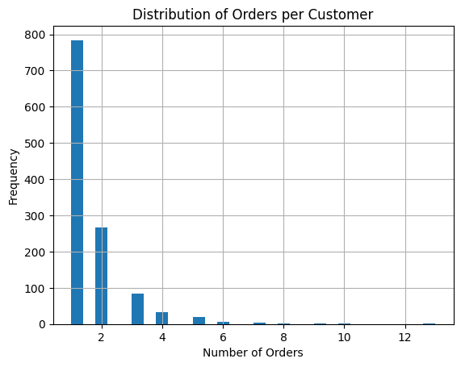

```python
# Histogram for all customers
customer_id_counts.hist(bins=30)
plt.xlabel('Number of Orders')
plt.ylabel('Frequency')
plt.title('Distribution of Orders per Customer')
plt.show()
```

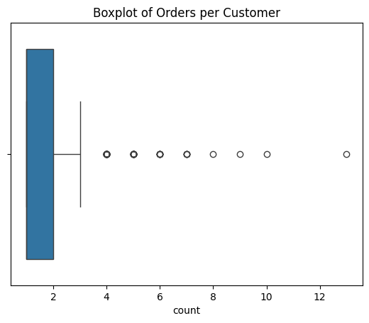

```python
snsboxplot = sns.boxplot(data= data,x=customer_id_counts)
snsboxplot.set_title('Boxplot of Orders per Customer')
plt.show()
```

```python
data['customer_id'].value_counts()
```

```
customer_id
52832     13
47440     10
83287      9
250494     8
259341     7
          ..
385426     1
254913     1
289597     1
74412      1
397537     1
Name: count, Length: 1200, dtype: int64
```

### Observation:

Most customers appear to place only 1 order, as indicated by the distribution. This suggests that a significant portion of the customer base does not return for additional purchases.

## 3) restaurant_name

```python
restaurant_counts = data['restaurant_name'].value_counts()

# Display top 10 customers with the most orders
print("Top 10 customers with the most orders:")
print(restaurant_counts.head(10))
```

```
Top 10 customers with the most orders:
restaurant_name
Shake Shack                      219
The Meatball Shop                132
Blue Ribbon Sushi                119
Blue Ribbon Fried Chicken         96
Parm                              68
RedFarm Broadway                  59
RedFarm Hudson                    55
TAO                               49
Han Dynasty                       46
Blue Ribbon Sushi Bar & Grill     44
Name: count, dtype: int64
```

### Observation:

The analysis of the restaurant_name shows that the top restaurant, Shake Shack, received 219 orders, significantly more than other establishments.Other popular restaurants include The Meatball Shop (132 orders) and Blue Ribbon Sushi (119 orders), indicating strong customer preferences for certain dining options.

```python
data['restaurant_name'].nunique() # Check for unique restaurant names
```

```
178
```

### Observation:

There are a total of 178 unique restaurants that customers have ordered from, showcasing a diverse selection in the dataset.

The concentration of orders among the top restaurants suggests that customer loyalty may play a significant role in ordering behavior, with a few establishments dominating the market.